# Web Scraping

Heber Esteban Bermúdez

Unalytics “https://unalyticsteam.github.io/unalytics.github.io/”

# Introducción

Muchas veces los datos que encontramos en la web no están formatos estructurados o ficheros que estamos a acostumbrados a manejar como xls, csv, csv2, txt, json, xml entre otros, es por eso que es necesario desarrollar una metodología diferente para poder acceder a dichos datos.

El web scraping es uno de los métodos más sólidos y confiables para obtener datos de internet y este nos permite extraer datos escondidos en un documento, como páginas web.

# ¿Para qué nos sirve web scraping?

[figure not shown]

- Rastreo de datos de sitios de redes sociales como Facebook y Twitter para realizar tareas Análisis de opiniones, extracción de opiniones, etc.
- Analizar la página web de la competencia (precios, promociones, contenido que generan)
- Rastreo de datos de texto de Wikipedia y otras fuentes para crear sistemas basados en PNL o entrenar modelos de aprendizaje profundo.
- Extraer los datos de imagen de sitios web como Google, Flickr, etc. para entrenar modelos de clasificación de imágenes.

# Estructura HTML5

[figure not shown]

Conocer la estructura de una página web es el primer paso para extraer y usar los datos.

- HTML es el acrónimo de Hypertext Markup Language y es el lenguaje utilizado para describir (marcado) páginas web y como tal es el lenguaje subyacente para estructurar el contenido de la página web. HTML no determina la apariencia de las cosas, solo ayuda a clasificar y estructurar el contenido.
- CSS (hojas de estilo en cascada) es un lenguaje que define la apariencia de un documento escrito en un lenguaje de marcado (por ejemplo, HTML).
- JavaScript (JS) es un lenguaje de programación interpretado que es implementado como parte de un navegador web permitiendo mejoras en la interfaz de usuario y páginas web dinámicas

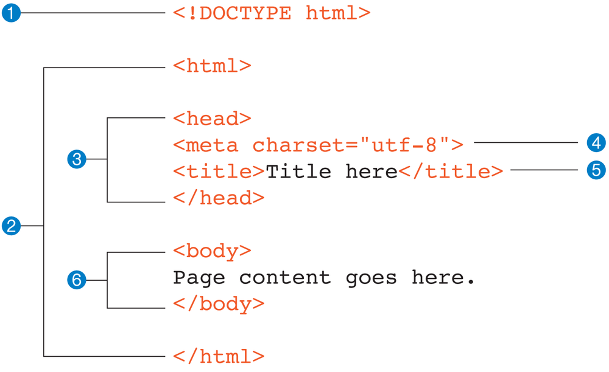

- 1 Tipo de documento (indica que estamos trabajando con html5)
- 2 Inicio y fin del documento html
- 3 Cabeza (aquí podemos hacer llamados a las hojas de estilos y JS)
- 4 Codificación
- 5 Título de la página web
- 6 Cuerpo (aquí va el contenido de la página web)

## Etiquetas basicas html

En el siguiente enlace encontrará un listado con las etiquetas básicas html

https://www.brandominus.com/todas-etiquetas-html5/

## Asignando id y clase a una etiqueta html.

```r
  <div id="about">    (Asignando id.)
  <div class="container">  (Asignando clase.)
```

## Selectores en CSS

#### Selectores de ID (se indica con #)

```r
 #about
```

#### Selectores de clase (se indica con . (punto))

```r
 .container
```

# rvest

rvest es un paquete que facilita la recolección de datos de páginas web html creado por Hadley Wickham (científico jefe de RStudio).

#### Instalación

```r
install.packages("rvest")
```

Funciones principales

read_html(url) : para leer el código html html_nodes() : para identificar los nodos html_nodes(“.class”) : llamado a los nodos basado en la clase CSS html_nodes(“#id”): llamado al nodo basado en el id de la etiqueta

html_table(): convierte tablas HTML en dataframe

# SelectorGadget (Google Chrome)

SelectorGadget es una herramienta de código abierto que nos indica el selector CSS de una sección especifica de una página web, con esto podemos identificar en que clase CSS esta determinado dato.

#### Instalación.

[figure not shown]

Imagen1. SelectorGadget

Una vez añadida la extensión esta aparecerá en la parte superior derecha del navegador.

Para saber cómo funciona, consulte:

https://selectorgadget.com/

# Ejemplo 1 (Clásico)

#### Cargado librería rvest al ambiente de trabajo

A continuación, se muestra como extraer información del rankin de películas de la pagina IMDb

```r
library(rvest)
#Especificar la url de la página de la que queremos extraer la información
url <- "https://www.imdb.com/search/title?count=100&release_date=2016,2016&title_type=feature"

# Leyendo el código HTML de la pagina
peliculas <- read_html(url)
```

### Extrayendo los titulos de las peliculas

```r
# Extrayendo el los nodos que contienen los títulos de las películas.
nodos_titulos <- html_nodes(peliculas, ".lister-item-header a")

# Convirtiendo a texto (siempre)
titulos_peliculas <- html_text(nodos_titulos)

# Mostremos los primeros 5 elementos de titulos_peliculas
head(titulos_peliculas, 5)
```

```
## [1] "Moonlight"
## [2] "La La Land"
## [3] "Fantastic Beasts and Where to Find Them"
## [4] "X-Men: Apocalypse"
## [5] "Split"
```

```r
# Verificamos que si sea el tipo de dato que deseamos
class(titulos_peliculas)
```

```
## [1] "character"
```

```r
#NOTA: podemos usar tuberias (hace exactamente lo mismo que el código de arriba)
titulos_peliculas <- peliculas %>% html_nodes(".lister-item-header a") %>% html_text()
```

### Extrayendo la descripción de las películas.

```r
# Extrayendo el los nodos que contienen la descripción de las películas.
nodos_descripcion <- html_nodes(peliculas, '.ratings-bar+ .text-muted')

# Convirtiendo a texto (siempre)
descripcion <- html_text(nodos_descripcion)

# Mostremos los primeros 3 elementos.
head(descripcion, 3)
```

```
## [1] "\n    A chronicle of the childhood, adolescence and burgeoning adulthood of a young, African-American, gay man growing up in a rough neighborhood of Miami."
## [2] "\n    While navigating their careers in Los Angeles, a pianist and an actress fall in love while attempting to reconcile their aspirations for the future."
## [3] "\n    The adventures of writer Newt Scamander in New York's secret community of witches and wizards seventy years before Harry Potter reads his book in school."
```

```r
# Limpiando, removiendo '\n'
descripcion_clean <- gsub("\n","",descripcion )

#Mostremos nuevamente los primeros 3 elementos.
head(descripcion_clean, 3)
```

```
## [1] "    A chronicle of the childhood, adolescence and burgeoning adulthood of a young, African-American, gay man growing up in a rough neighborhood of Miami."
## [2] "    While navigating their careers in Los Angeles, a pianist and an actress fall in love while attempting to reconcile their aspirations for the future."
## [3] "    The adventures of writer Newt Scamander in New York's secret community of witches and wizards seventy years before Harry Potter reads his book in school."
```

### Sacando la duración de la película

```r
# Extrayendo los nodos que contienen la duración de las películas.
nodos_duracion <- html_nodes(peliculas, '.runtime')

# Convirtiendo a texto (siempre)
duracion <- html_text(nodos_duracion)
head(duracion, 3)
```

```
## [1] "111 min" "128 min" "133 min"
```

```r
# Limpiando, removiendo 'min'
duracion_clean <-gsub("min","",duracion )

# Mostrado los primeros 3 elementos
head(duracion_clean, 3)
```

```
## [1] "111 " "128 " "133 "
```

```r
# convirtiendo a tipo de variable deseada
duracion_clean <- as.numeric(duracion_clean)
```

### Extrayendo Calificación de las películas

```r
# Extrayendo los nodos de calificación de las películas
nodos_calificacion <- html_nodes(peliculas, '.ratings-imdb-rating strong')

# Convirtiendo a texto (siempre)
calificacion <- html_text(nodos_calificacion)

# convirtiendo a variable deseada.
calificacion <- as.numeric(calificacion)
```

### Creando nuestro data.frame

```r
datos <- data.frame(titulos_peliculas, descripcion_clean, duracion_clean, calificacion)
```

### Grafico

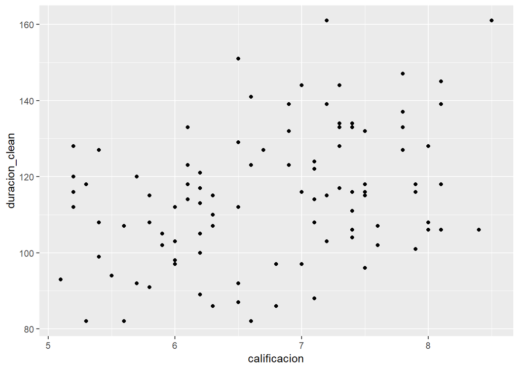

```r
library(ggplot2)
ggplot (datos, aes(x = calificacion, y = duracion_clean)) + geom_point()
```

# Ejemplo 2.

# Legalidad

Algunos sitios web se oponen a ser rastreados, ya sea por el aumento de las cargas del servidor o por preocupaciones sobre la propiedad de los datos. Si un sitio web prohíbe raspar los Términos de uso, es ilegal.

# Interesante

Extraer datos de twitter : https://rpubs.com/camilamila/tweets2